# Tugas 2 Praktikum MPDW

# Nomor 1

## Impor Data

```r
library(readxl)
data1 <- read_excel(
  "C:/Users/Abit/Documents/KULIAH SMT 5/MPDW/Tugas Praktikum 2.xlsx",
  sheet = "Sheet1"
)

head(data1)
```

```
## # A tibble: 6 × 3
##   Period `Market share` Price
##    <dbl> <chr>          <chr>
## 1      1 3.63           0.97
## 2      2 4.20           0.95
## 3      3 3.33           0.99
## 4      4 4.54           0.91
## 5      5 2.89           0.98
## 6      6 4.87           0.90
```

## Pemodelan Regresi OLS

```r
data1$`Market share` <- as.numeric(data1$`Market share`)
data1$Price <- as.numeric(data1$Price)

# Regresi OLS
model_ols <- lm(`Market share` ~ Price, data = data1)

# Melihat hasil regresi
summary(model_ols)
```

```
##
## Call:
## lm(formula = `Market share` ~ Price, data = data1)
##
## Residuals:
##      Min       1Q   Median       3Q      Max
## -0.73068 -0.29764 -0.00966  0.30224  0.81193
##
## Coefficients:
##             Estimate Std. Error t value Pr(>|t|)
## (Intercept)   26.910      1.110   24.25 3.39e-15 ***
## Price        -24.290      1.298  -18.72 3.02e-13 ***
## ---
## Signif. codes:  0 '***' 0.001 '**' 0.01 '*' 0.05 '.' 0.1 ' ' 1
##
## Residual standard error: 0.4287 on 18 degrees of freedom
## Multiple R-squared:  0.9511, Adjusted R-squared:  0.9484
## F-statistic: 350.3 on 1 and 18 DF,  p-value: 3.019e-13
```

## Identifikasi Autokorelasi

### ACF dan PACF identifikasi autokorelasi

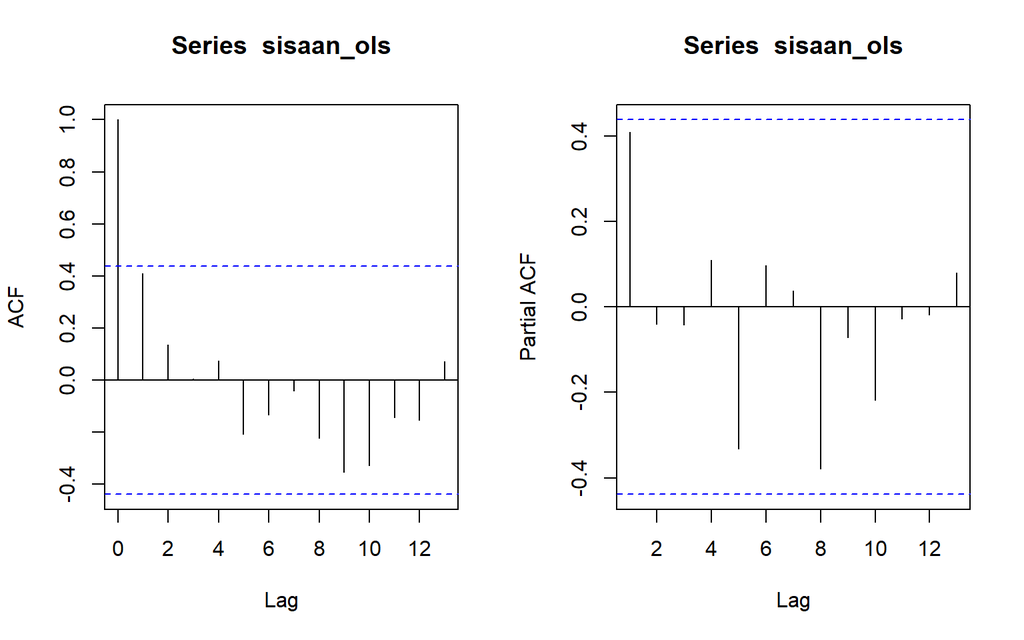

```r
sisaan_ols <- residuals(model_ols)
par(mfrow = c(1,2))
acf(sisaan_ols)
pacf(sisaan_ols)
```

### Pemeriksaan dengan Durbin Test

```r
library(lmtest)
dw_ols <- dwtest(model_ols)
dw_ols
```

```
##
##  Durbin-Watson test
##
## data:  model_ols
## DW = 1.1358, p-value = 0.009813
## alternative hypothesis: true autocorrelation is greater than 0
```

Karena p-value (0,009813) < α (0,05), H0 ditolak, dan nilai DW = 1,1358 yang jauh di bawah 2 menunjukkan adanya autokorelasi positif pada sisaan model.

## Penanganan Autokorelasi dengan Metode Cochrane-Orcutt

```r
library(orcutt)

modelCO_ols <- cochrane.orcutt(model_ols)
summary(modelCO_ols)
```

```
## Call:
## lm(formula = `Market share` ~ Price, data = data1)
##
##             Estimate Std. Error t value  Pr(>|t|)
## (Intercept)  26.7221     1.6329  16.365 7.713e-12 ***
## Price       -24.0841     1.9385 -12.424 5.903e-10 ***
## ---
## Signif. codes:  0 '***' 0.001 '**' 0.01 '*' 0.05 '.' 0.1 ' ' 1
##
## Residual standard error: 0.3955 on 17 degrees of freedom
## Multiple R-squared:  0.9008 ,  Adjusted R-squared:  0.895
## F-statistic: 154.4 on 1 and 17 DF,  p-value: < 5.903e-10
##
## Durbin-Watson statistic
## (original):    1.13582 , p-value: 9.813e-03
## (transformed): 1.95804 , p-value: 4.151e-01
```

```r
dw_olsCO <- dwtest(modelCO_ols)
dw_olsCO
```

```
##
##  Durbin-Watson test
##
## data:  modelCO_ols
## DW = 1.958, p-value = 0.4151
## alternative hypothesis: true autocorrelation is greater than 0
```

```r
# Uji Durbin-Watson sesudah Orcutt
dw_olsCO <- dwtest(modelCO_ols)

# Membandingkan DW sebelum dan sesudah Cochrane-Orcutt
dw_compare <- data.frame(
  Model = c("Sebelum Orcutt", "Sesudah Orcutt"),
  DW = c(dw_ols$statistic, dw_olsCO$statistic),
  p_value = c(dw_ols$p.value, dw_olsCO$p.value)
)
dw_compare
```

```
##            Model       DW     p_value
## 1 Sebelum Orcutt 1.135816 0.009813346
## 2 Sesudah Orcutt 1.958041 0.415141765
```

Berdasarkan hasil uji Durbin-Watson, autokorelasi pada model telah berhasil ditangani. Sebelum koreksi, DW = 1,1358 dengan p-value = 0,0098 (< α = 0,05), menunjukkan adanya autokorelasi positif pada sisaan. Setelah dilakukan koreksi dengan metode Cochrane-Orcutt, DW meningkat menjadi 1,958 dengan p-value = 0,4151 (> α = 0,05), sehingga gagal tolak H0. Nilai DW yang mendekati 2 ini mengindikasikan bahwa autokorelasi pada model sudah tidak signifikan, artinya penanganan dengan Cochrane-Orcutt berhasil mengatasi masalah autokorelasi pada model regresi.

# Nomor 2

## Import Data

```r
library(readxl)

data2 <- read_excel(
  "C:/Users/Abit/Documents/KULIAH SMT 5/MPDW/Tugas Praktikum 2.xlsx",
  sheet = "Sheet2"
)

head(data2)
```

```
## # A tibble: 6 × 3
##    Year Sales Advertising
##   <dbl> <dbl>       <dbl>
## 1  1975  11.7         9.4
## 2  1976  12           9.6
## 3  1977  12.3        10
## 4  1978  12.8        10.4
## 5  1979  13.1        10.8
## 6  1980  13.6        10.9
```

## Pemodelan Regresi OLS

```r
# Regresi OLS
model_ols2 <- lm(Sales ~ Advertising, data = data2)

# Melihat hasil regresi
summary(model_ols2)
```

```
##
## Call:
## lm(formula = Sales ~ Advertising, data = data2)
##
## Residuals:
##      Min       1Q   Median       3Q      Max
## -1.03758 -0.40343  0.08933  0.45674  0.74036
##
## Coefficients:
##             Estimate Std. Error t value Pr(>|t|)
## (Intercept)  5.96513    0.38092   15.66   <2e-16 ***
## Advertising  0.71035    0.02365   30.04   <2e-16 ***
## ---
## Signif. codes:  0 '***' 0.001 '**' 0.01 '*' 0.05 '.' 0.1 ' ' 1
##
## Residual standard error: 0.527 on 38 degrees of freedom
## Multiple R-squared:  0.9596, Adjusted R-squared:  0.9585
## F-statistic: 902.3 on 1 and 38 DF,  p-value: < 2.2e-16
```

## Identifikasi Autokorelasi

### ACF dan PACF identifikasi autokorelasi

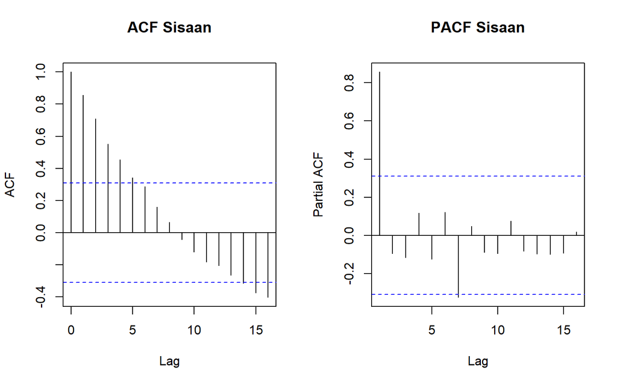

```r
sisaan_ols2 <- residuals(model_ols2)

par(mfrow = c(1,2))
acf(sisaan_ols2, main = "ACF Sisaan")
pacf(sisaan_ols2, main = "PACF Sisaan")
```

### Pemeriksaan dengan Durbin Test

```r
dw_ols2 <- dwtest(model_ols2)
dw_ols2
```

```
##
##  Durbin-Watson test
##
## data:  model_ols2
## DW = 0.16204, p-value < 2.2e-16
## alternative hypothesis: true autocorrelation is greater than 0
```

Nilai DW = 0,162 yang jauh di bawah 2 menunjukkan adanya autokorelasi positif pada sisaan model.

## Penanganan Autokorelasi dengan Metode Cochrane-Orcutt

```r
library(orcutt)

modelCO2_ols <- cochrane.orcutt(model_ols2)
summary(modelCO2_ols)
```

```
## Call:
## lm(formula = Sales ~ Advertising, data = data2)
##
##              Estimate Std. Error t value  Pr(>|t|)
## (Intercept) 10.252375   1.459736   7.023 2.638e-08 ***
## Advertising  0.488489   0.075426   6.476 1.426e-07 ***
## ---
## Signif. codes:  0 '***' 0.001 '**' 0.01 '*' 0.05 '.' 0.1 ' ' 1
##
## Residual standard error: 0.1868 on 37 degrees of freedom
## Multiple R-squared:  0.5313 ,  Adjusted R-squared:  0.5186
## F-statistic: 41.9 on 1 and 37 DF,  p-value: < 1.426e-07
##
## Durbin-Watson statistic
## (original):    0.16204 , p-value: 8.935e-20
## (transformed): 1.93925 , p-value: 3.78e-01
```

```r
dw_olsCO2 <- dwtest(modelCO2_ols)
dw_olsCO2
```

```
##
##  Durbin-Watson test
##
## data:  modelCO2_ols
## DW = 1.9393, p-value = 0.378
## alternative hypothesis: true autocorrelation is greater than 0
```

```r
# Uji Durbin-Watson sesudah Orcutt
dw_olsCO2 <- dwtest(modelCO2_ols)

# Membandingkan DW sebelum dan sesudah Cochrane-Orcutt
dw_compare2 <- data.frame(
  Model = c("Sebelum Orcutt", "Sesudah Orcutt"),
  DW = c(dw_ols2$statistic, dw_olsCO2$statistic),
  p_value = c(dw_ols2$p.value, dw_olsCO2$p.value)
)
dw_compare2
```

```
##            Model        DW      p_value
## 1 Sebelum Orcutt 0.1620428 8.935306e-20
## 2 Sesudah Orcutt 1.9392537 3.780214e-01
```

Berdasarkan hasil uji Durbin-Watson, autokorelasi pada model kedua ini juga telah berhasil ditangani. Sebelum koreksi, DW = 0,1620 dengan p-value = 8,94 × 10⁻²⁰ (< α = 0,05), menunjukkan adanya autokorelasi positif yang sangat kuat pada sisaan. Setelah dilakukan koreksi dengan metode Cochrane-Orcutt, DW meningkat menjadi 1,9393 dengan p-value = 0,3780 (> α = 0,05), sehingga gagal tolak H0. Nilai DW yang mendekati 2 ini mengindikasikan bahwa autokorelasi pada model sudah tidak signifikan, artinya penanganan dengan Cochrane-Orcutt berhasil mengatasi masalah autokorelasi pada model regresi ini.